# Rwanda Soil Health Study

Yield Paired Round 1

Matt Lowes

August 07, 2017

# 1 Objectives

The objectives of this notebook are to analyze the results from the first follow up round of the Rwanda long term soil health study.

# 2 Key Takeaways

> Paired Yield and Soil ids are a mess. We lose a lot of observations due to unreconciliable duplicates or ids that simply don’t have a match. We lose almost 500 observations.

> See initial yield response analysis

TODO - check projection from baseline maps, are they shifted over? TODO - how to connect photos to farmers for enumerators

# 3 Data Prep

```r
dataDir <- normalizePath(file.path("..", "..", "data"))
forceUpdateAll <- FALSE
source("../oaflib/commcareExport.R")
```

How do soil attributes predict yields (climbing beans) >> can we understand yield as functions of carbon, pH, etc. Are the curves as we might expect?

## 3.1 Load yield data

The variable names from Commcare are in Kinyarwanda and a bit of a mess. I’m going to try to use the names from the Commcare form export. Or is there a way to get this information from Commcare? Surely there must be.

```r
bean <- getFormData("oafrwanda", "M&E", "16B ALL Isarura (Harvest)", forceUpdate = forceUpdateAll)
```

```
[1] "found 736b25426bb4f9320a07d9c42b738ea"
```

```r
write.csv(bean, file="rawCcYpData.csv", row.names=F)
yieldNames <- read.table(unz("2016B Harvest2017-06-08.zip", "Forms.csv"), nrows=10, header=T, quote="\"", sep=",") # only first 10 rows
# print variable names together
write.csv(data.frame(names(bean)[1:100], names(yieldNames)[1:100]), file="matchYieldNames.csv")
# get names from cc
# appName <- "M&E"
# formName <- "16B ALL Isarura (Harvest)"
# moduleIdx=NA
appData <- getAppStructure("oafrwanda")
enNames <- getFormFromApp(appData, "M&E", "16B ALL Isarura (Harvest)")$values
# leads to duplicates
onlyVarName <- strsplit(enNames, "/", fixed=F)
newNames <- do.call(rbind, lapply(onlyVarName, function(x){
  return(x[[length(x)]])
}))
names(bean)[11:length(names(bean))] <- newNames #had to change this to 11 on 8/2 due to come CC API update?
#names(bean)[duplicated(names(bean))]
# update intercrop names so that they're unique >> manual cleaning
names(bean)[61:70] <- paste("plants_box1", names(bean)[61:70], sep="_")
names(bean)[82:91] <- paste("plants_box2", names(bean)[82:91], sep="_")
names(bean)[170] <- paste0("climbing_beans_", names(bean)[170])
names(bean)[177] <- paste0("bush_beans_", names(bean)[177])
names(bean)[171] <- paste0("climbing_beans_", names(bean)[171])
names(bean)[178] <- paste0("bush_beans_", names(bean)[178])
names(bean)[173] <- paste0("climbing_beans_", names(bean)[173])
names(bean)[180] <- paste0("bush_beans_", names(bean)[180])
names(bean)[174] <- paste0("climbing_beans_", names(bean)[174])
names(bean)[181] <- paste0("bush_beans_", names(bean)[181])
names(bean)[211] <- paste0("bush_beans", names(bean)[211])
names(bean)[221] <- paste0("maize_", names(bean)[221])
#deal with duplicated variable names
names(bean)[duplicated(names(bean))] <- paste0(names(bean)[duplicated(names(bean))],"_1")
```

The best version of English names don’t come from the data labels. They come from another portion of the output. I’ve extracted it here but a key point of feedback for Nathaniel will be to make certain that going forward variable labels are in the right places.

## 3.2 Load soil

It’s probably safe to assume that if there isn’t a soil code the data can be dropped. It’s not clear how to match the yield data to the soil data. There might be a way to use the client id from the SHS data but I also don’t know if that maps to the M&E data. I could try it if Nathaniel doesn’t have a suggestion.

```r
#names(bean)[grep("soil",names(bean))]
#names(bean)[grep("id",names(bean))]
#table(bean$soil_code, useNA = 'ifany')
pairedSoilDir <- normalizePath(file.path("..", "..", "OAF Soil Lab Folder", "Projects", "rw_shs_16b_paired_climbing", "4_predicted", "other_summaries"))
pairedSoil <- read.csv(file=paste(pairedSoilDir, "combined-predictions-including-bad-ones.csv", sep = "/"))
pSoilIdDir <- normalizePath(file.path("..", "..", "OAF Soil Lab Folder", "Projects", "rw_shs_16b_paired_climbing", "5_merged"))
pSoilIds <- read.csv(file=paste(pSoilIdDir, "database.csv", sep = "/"))
```

### 3.2.1 Clean soil ids

Helpful links: [mutate_each](https://stackoverflow.com/questions/27027347/mutate-each-summarise-each-in-dplyr-how-do-i-select-certain-columns-and-give) and [var names to lower](https://stackoverflow.com/questions/29264028/dplyr-or-magrittr-tolower)

```r
psi <- pSoilIds %>%
  setNames(tolower(names(.))) %>%
  mutate_each(funs(tolower), district, cell) %>%
  rename(ssn = lab.ssn) %>%
  mutate(
    idDups = duplicated(id) | duplicated(.[nrow(.):1, "id"])[nrow(.):1],
    ssnDups = duplicated(ssn) | duplicated(.[nrow(.):1, "ssn"])[nrow(.):1]
  )
pairedSoil <- pairedSoil %>%
  setNames(tolower(names(.)))
#table(psi$ssn %in% pairedSoil$ssn) # FALSE  TRUE  41   703
#table(pairedSoil$ssn %in% psi$ssn) # FALSE  TRUE  27   703
pairedSoil <- left_join(pairedSoil, psi, by="ssn") # keeps all paired soil values, no duplicated ids
```

And now check how many soil ids are duplicated in the bean data. Is there any hope of untangling which ones are suppoed to be which based on the info provided in the soil data?

```r
beanCheck <- bean %>%
  filter(!is.na(soil_code)) %>%
  mutate(
    idDups = duplicated(soil_code) | duplicated(.[nrow(.):1, "soil_code"])[nrow(.):1]
  )
beanCheck %>%
  filter(idDups==TRUE) %>%
  arrange(soil_code) %>%
  dplyr::select(district, cell, soil_code)
```

| district | cell | soil_code |
| --- | --- | --- |
| bugarama | Butanda | -88 |
| bugarama | Nyabintare | -88 |
| bugarama | Nyabintare | -88 |
| bugarama | Nyabintare | -88 |
| bugarama | Gasebeya B | -88 |
| bugarama | Butanda | -88 |
| bugarama | Butanda | -88 |
| karongi | Kabingo | -88 |
| bugarama | Higiro | -88 |
| bugarama | Higiro | -88 |

[output cut: 69 more lines]

And let’s compare this to the ids in the soil data to see if we can find matches. If I can, I’ll need to make a new unique id to match them.

```r
#vector of duplicated ids in the bean data
idComps <- unique(beanCheck$soil_code[beanCheck$idDups==TRUE])
pairedSoil %>%
  filter(id %in% idComps) %>%
  arrange(id) %>%
  dplyr::select(district, cell, id)
```

| district | cell | id |
| --- | --- | --- |
| karongi | gitega g | 24764 |
| rusizi | murambi | 44337 |
| rusizi | muyange | 183004 |
| nyamagabe | kibyagira b | 1326301 |
| lww | nyarusangeb | 9050401 |
| nyamasheke | kigoya | 14160102 |

Visually it doesn’t seem that there are easy matches to be made. We obviously don’t have any -88s or 0s in the id data.

- `24764` Gitega g doesn’t exist.
- `44337` There are two murambi and we have no further distinguishing info.
- `183004` the name is entirely different.
- `1326301` kibyagira seems to be the best match!
- `9050401` the names are the same.
- `14160102` the names are the same.

Fix the one duplicate we can, drop the others and merge the yield data with the soil data. TODO - still waiting on Nathaniel for guidance on how to calculate climbing bean yield. I can take a look at this and see if I can guess.

TODO - follow up with Nathaniel about the soil ids not matching.

```r
bean <- bean[-which(bean$soil_code==1326301 & bean$cell=="Gahira"),]
```

```r
py <- bean %>%
  filter(!is.na(soil_code)) %>%
  mutate(
    idDups = duplicated(soil_code) | duplicated(.[nrow(.):1, "soil_code"])[nrow(.):1]
  ) %>%
  filter(idDups==FALSE) %>%
  rename(ns = id, # change the bean id to something else,  nonsense
         id = soil_code)
```

We lose 281 obs to duplicated or useless ids.

```r
loss <- table(py$id %in% pairedSoil$id)[[1]]
#py$id[!py$id %in% pairedSoil$id]
#table(pairedSoil$id %in% py$id)
```

We then lose 203 to not having matches. We’re not getting good value for our money here.

```r
toJoin <- names(pairedSoil)[c(2:22,25)]
py <- py %>%
  inner_join(., pairedSoil[,toJoin], by="id")
```

## 3.3 Clean and construct vars

I’m going to take a quick guess at how kg/m2 and t/ha yield calculations were made so that I can set up the analyses I want. I’m first incorporating chagnes to the data Alex Villec did in his .do file. See `cleans_harvest_16b.do` starting on line 85.

```r
py$box_length1 <- ifelse(py$d_box_lenght1!=7 & py$d_box_lenght1!=3, 5, py$d_box_lenght1)
py$box_width1 <- ifelse(py$d_box_width1!=7 & py$d_box_width1!=3, 5, py$d_box_width1)
py$box_length2 <- ifelse(py$d_box_length2!=7 & py$d_box_length2!=3, 5, py$d_box_length2)
py$box_width2 <- ifelse(py$d_box_width2!=7 & py$d_box_width2!=3, 5, py$d_box_width2)
```

```r
calculateYield <- function(bagA, bagB, lenA, lenB, widthA, widthB, df) {

  #convert to numeric
  df[,c(bagA, bagB, lenA, lenB, widthA, widthB)] <- sapply(df[,c(bagA, bagB, lenA, lenB, widthA, widthB)], function(x){
    as.numeric(as.character(x))
  })

  # calculate box areas
  df$boxAreaA <- df[,lenA] * df[,widthA]
  df$boxAreaB <- df[,lenB] * df[,widthB]
  df$yieldA <- df[,bagA] / df$boxAreaA
  df$yieldB <- df[,bagB] / df$boxAreaB
  df$yieldProbsA <- is.na(df$yieldA) | is.infinite(df$yieldA)
  df$yieldProbsB <- is.na(df$yieldB) | is.infinite(df$yieldB)
  df$yield <- (df[,bagA] + df[,bagB]) / (df$boxAreaA + df$boxAreaB)

  df$yield[!df$yieldProbsA & df$yieldProbsB] <-
    df$yieldA[!df$yieldProbsA & df$yieldProbsB]
  df$yield[!df$yieldProbsB & df$yieldProbsA] <-
    df$yieldB[!df$yieldProbsB & df$yieldProbsA]
  return(df)
}
py <- calculateYield("box_kg1", "box_kg2", "box_length1", "box_length2", "box_width1", "box_width2", py)
respVar <- c(names(py)[which(names(py)=="ph"): which(names(py)=="x.total.nitrogen")], "yield")
#yr <- py[,names(py) %in% respVar]
py$tha <- py$yield * 10
soilVars <- names(py)[which(names(py)=="ph"):which(names(py)=="x.total.nitrogen")]
keySoilVars <- c("ph", "x.organic.carbon", "x.total.nitrogen", "calcium", "magnesium")
```

```r
iqr.check <- function(dat, x) {
  q1 = summary(dat[,x])[[2]]
  q3 = summary(dat[,x])[[5]]
  iqr = q3-q1
  mark  = ifelse(dat[,x] < (q1 - (1.5*iqr)) | dat[,x] > (q3 + (1.5*iqr)), 1,0)
  tab = rbind(
    summary(dat[,x]),
    summary(dat[mark==0, x])
  )
  return(tab)
}
soilYTab <- do.call(plyr::rbind.fill, lapply(soilVars, function(y){
  #print(y)
  res = iqr.check(py, y)
  #print(dim(res))
  out = data.frame(var=rbind(y, paste(y, ".iqr", sep="")), res)
  return(out)
}))
soilYTab[,2:length(soilYTab)] <- sapply(soilYTab[,2:length(soilYTab)], function(x){round(x,2)})
```

The outlier table summarizes the numeric variables with and without IQR outliers to show how the data changes based on this filter.

```r
knitr::kable(soilYTab, row.names = F, digits = 3, format = 'markdown')
```

| var | Min. | X1st.Qu. | Median | Mean | X3rd.Qu. | Max. |
| --- | --- | --- | --- | --- | --- | --- |
| ph | 4.44 | 5.19 | 5.49 | 5.55 | 5.83 | 9.06 |
| ph.iqr | 4.44 | 5.18 | 5.48 | 5.50 | 5.80 | 6.78 |
| x.ec..salts. | 32.26 | 51.37 | 58.24 | 62.07 | 69.06 | 115.30 |
| x.ec..salts..iqr | 32.26 | 51.00 | 57.89 | 60.17 | 67.32 | 95.29 |
| phosphorus | 5.85 | 12.85 | 18.31 | 21.23 | 25.29 | 97.86 |
| phosphorus.iqr | 5.85 | 12.55 | 17.48 | 19.09 | 24.01 | 43.40 |
| potassium | 94.21 | 142.20 | 157.70 | 164.70 | 182.70 | 273.40 |
| potassium.iqr | 94.21 | 141.50 | 156.70 | 162.70 | 180.70 | 243.10 |
| calcium | 135.60 | 406.80 | 596.60 | 778.70 | 895.30 | 6894.00 |
| calcium.iqr | 135.60 | 398.60 | 560.20 | 629.10 | 806.60 | 1623.00 |
| magnesium | 28.96 | 92.46 | 140.20 | 187.60 | 212.70 | 1799.00 |
| magnesium.iqr | 28.96 | 89.15 | 129.60 | 145.60 | 189.50 | 390.70 |
| manganese | 9.46 | 29.44 | 52.44 | 68.13 | 86.11 | 402.40 |
| manganese.iqr | 9.46 | 28.54 | 48.68 | 57.97 | 78.46 | 170.70 |
| sulphur | 2.00 | 11.62 | 15.63 | 16.33 | 20.43 | 43.34 |
| sulphur.iqr | 2.00 | 11.60 | 15.51 | 16.08 | 20.32 | 31.79 |
| boron | 0.07 | 0.15 | 0.21 | 0.23 | 0.27 | 0.83 |
| boron.iqr | 0.07 | 0.15 | 0.20 | 0.21 | 0.26 | 0.45 |
| zinc | 0.57 | 1.69 | 2.46 | 3.17 | 3.46 | 136.00 |
| zinc.iqr | 0.57 | 1.64 | 2.36 | 2.57 | 3.23 | 6.12 |
| x.c.e.c | 3.35 | 6.32 | 7.68 | 9.18 | 10.36 | 45.81 |
| x.c.e.c.iqr | 3.35 | 6.21 | 7.44 | 8.12 | 9.60 | 16.38 |
| x.exchangeable.aluminium | 0.00 | 0.05 | 0.10 | 0.23 | 0.25 | 5.06 |
| x.exchangeable.aluminium.iqr | 0.00 | 0.04 | 0.09 | 0.13 | 0.17 | 0.55 |
| x.exchangeable.acidity | 0.02 | 0.17 | 0.36 | 0.68 | 0.87 | 4.77 |
| x.exchangeable.acidity.iqr | 0.02 | 0.16 | 0.33 | 0.51 | 0.76 | 1.90 |
| copper | 0.96 | 1.97 | 2.38 | 2.48 | 2.85 | 5.67 |
| copper.iqr | 0.96 | 1.96 | 2.36 | 2.44 | 2.80 | 4.17 |
| aluminium | 543.10 | 844.20 | 995.20 | 1040.00 | 1230.00 | 1794.00 |
| aluminium.iqr | 543.10 | 844.20 | 995.20 | 1040.00 | 1230.00 | 1794.00 |
| x.sodium | 21.39 | 38.33 | 43.83 | 43.73 | 49.01 | 84.82 |
| x.sodium.iqr | 22.90 | 38.33 | 43.78 | 43.53 | 48.89 | 65.00 |
| iron | 124.00 | 187.50 | 206.40 | 215.30 | 234.60 | 415.20 |
| iron.iqr | 124.00 | 186.10 | 205.20 | 209.60 | 229.50 | 304.20 |
| x.phosphorus.sorption.index..psi. | 43.87 | 84.79 | 130.30 | 142.60 | 188.10 | 342.00 |
| x.phosphorus.sorption.index..psi..iqr | 43.87 | 84.79 | 130.30 | 142.60 | 188.10 | 342.00 |
| x.organic.carbon | 1.21 | 1.73 | 1.93 | 2.01 | 2.21 | 3.63 |
| x.organic.carbon.iqr | 1.21 | 1.71 | 1.90 | 1.96 | 2.17 | 2.91 |
| x.total.nitrogen | 0.10 | 0.13 | 0.14 | 0.15 | 0.17 | 0.26 |
| x.total.nitrogen.iqr | 0.10 | 0.13 | 0.14 | 0.14 | 0.16 | 0.21 |

Impose sensible constraints on soil variables

**Ask Patrick and Step what those might be**. The table above removes IQR outliers. The check below removes based on 3sd so the values are different.

```r
check.3sd <- function(x) {
  x = ifelse(is.infinite(x), NA, x)
  mean = mean(x, na.rm=T)
  sd = sd(x, na.rm=T)
  mark = ifelse(x>(mean + (3*sd)) |
        x<(mean - (3*sd)), NA, x)
  return(mark)
}
sdSoilVals.py <- py %>%
  dplyr::select(one_of(soilVars))
sdCheck.py <- as.data.frame(apply(sdSoilVals.py, 2, function(x){
  return(check.3sd(x))
}))
names(py)[which(names(py)=="ph"):which(names(py)=="x.total.nitrogen")] <- paste0(names(py)[which(names(py)=="ph"):which(names(py)=="x.total.nitrogen")], ".raw")
py <- cbind(py, sdCheck.py)
```

# 4 Point of diminishing returns

The best option would be to identify it visually. However, we are not seeing a clear point of diminishing returns visually suggesting that our data doesn’t support this hypothesis of a point of diminishing returns despite there being an accepted theoretical point.

## 4.1 Pure one to one

Graphs to show the relationship between soil parameter and yield. We don’t expect this relationships to be linear. A couple notes:

- None seems to show any clear increasing or decreasing value across the spectrum of yield values.
- Nitrogen has a bimodal appearance with the second hump at 0.25. Why do we not have support for the values between 0.2 and 0.25?
- Magnesium seems to have a long right tail still.

**The goal is to identify the point of diminishing returns for the simplistic soil parameter yield model**

The actual relationship is likely more complex but defining that model is outside the scope of this research. If we were to include other parameters in the model, we’d have to run simluations to determine the global minimum for ph based all values of calcium, magnesium, and whatever else we add in the model. If we had multiple additional coefficients, it gets hugely complicated.

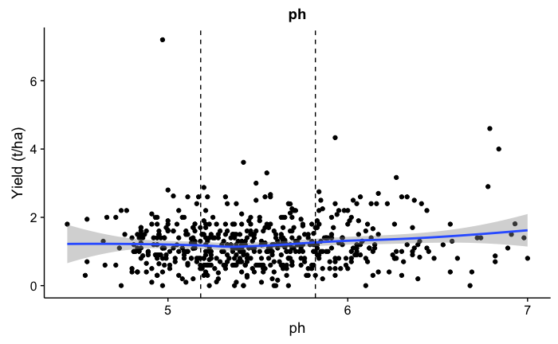

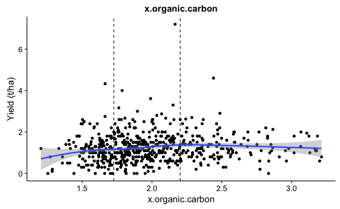

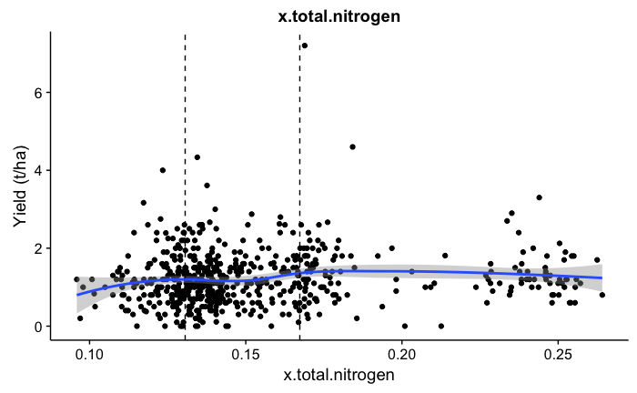

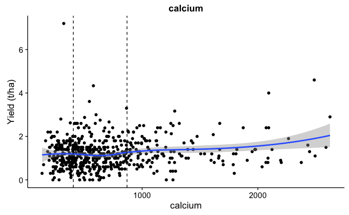

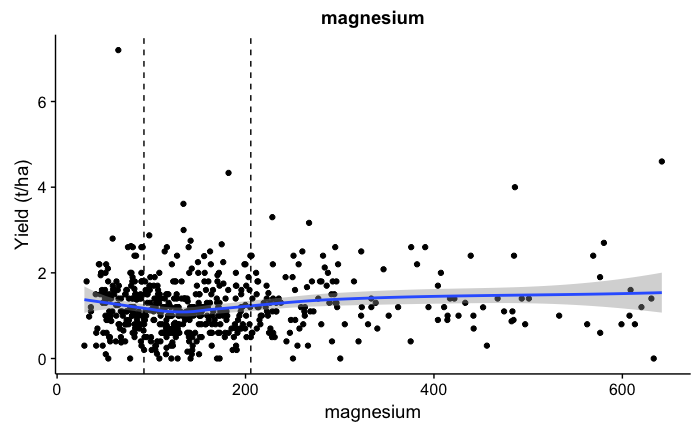

```r
for(i in 1:length(keySoilVars)){
  print(
  ggplot(py, aes(x = py[,keySoilVars[i]], y = tha)) +
    geom_point() +
    stat_smooth() +
    geom_vline(xintercept=summary(py[,keySoilVars[i]])[[2]], linetype="dashed") +
    geom_vline(xintercept=summary(py[,keySoilVars[i]])[[5]], linetype="dashed") +
    labs(title = keySoilVars[i], x= keySoilVars[i], y="Yield (t/ha)")
  )
}
```

- For each soil parameter, first write out the theoretical model, for instance quadradic relationship between ph and yield
- solve for where ph2 cancels out ph coefficient
- timing is not great as these are taken at harvest as opposed
- Try aggregating to a higher geographic level, average ph on average yield

```r
pdrFunction <- function(dat, var, outcome){
  powerVar = dat[,var]^2

  mod = lm(outcome ~ dat[,var] + powerVar, data=dat)

  if(summary(mod)$coeff[3]<0){
    beta1 <- summary(mod)$coeff[2]
    beta2 <- summary(mod)$coeff[3]
    keyPoint <- round((-beta1)/(2*beta2),2)
    tab = data.frame(var = var, result = keyPoint)
    return(tab)
  }else{
    return(data.frame(var = var, result= "NR"))
  }

}
```

```r
indPdrTab <- do.call(rbind, lapply(keySoilVars, function(x){
  pdrFunction(py, x, py$tha)
}))
kable(indPdrTab, format="markdown")
```

| var | result |
| --- | --- |
| ph | NR |
| x.organic.carbon | 2.44 |
| x.total.nitrogen | 0.2 |
| calcium | NR |
| magnesium | NR |

## 4.2 Log response

Try a log response to see if visually we get a better fit. We don’t really seem to.

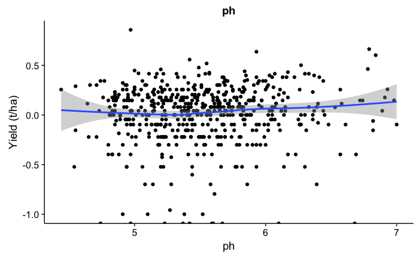

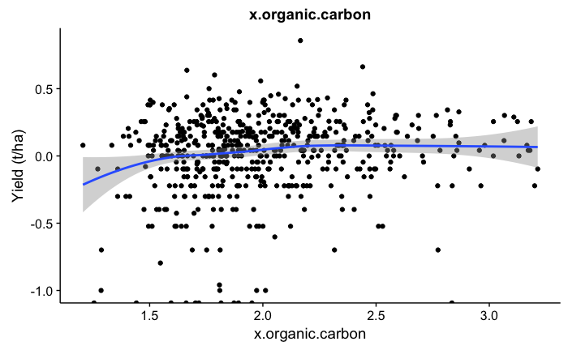

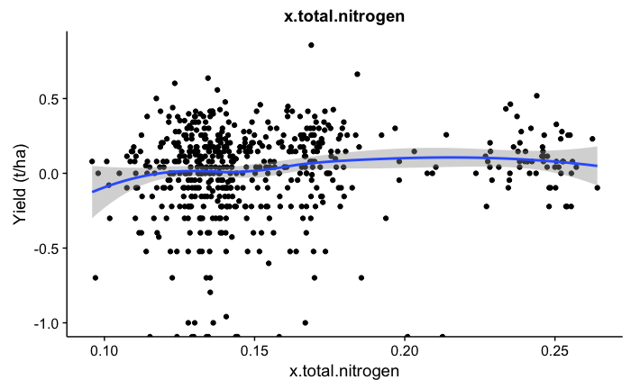

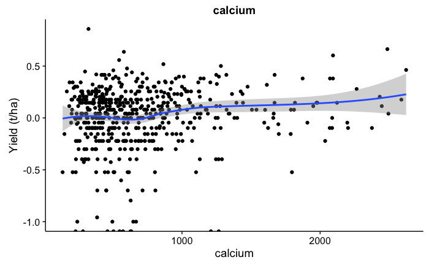

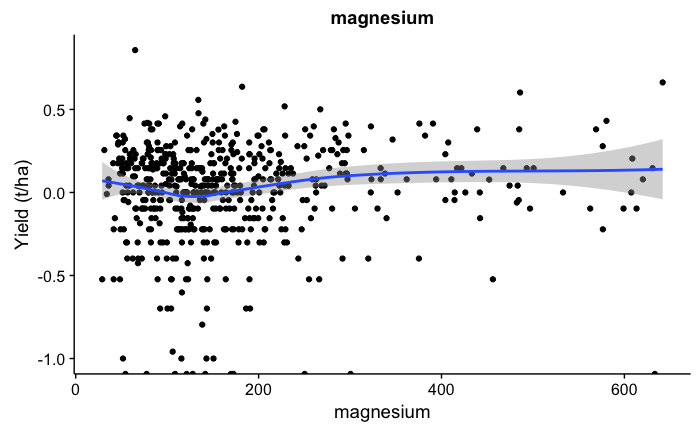

```r
for(i in 1:length(keySoilVars)){
  print(
  ggplot(py, aes(x = py[,keySoilVars[i]], y = log10(tha))) +
    geom_point() +
    stat_smooth() +
    #geom_vline(xintercept=summary(py[,keySoilVars[i]])[[2]], linetype="dashed") +
    #geom_vline(xintercept=summary(py[,keySoilVars[i]])[[5]], linetype="dashed") +
    labs(title = keySoilVars[i], x= keySoilVars[i], y="Yield (t/ha)")
  )
}
```

## 4.3 Cell level model

Aggregate data to the cell level to hopefully tame some of the noise in the individual measurement.

```r
py$cell <- tolower(py$cell)
aggCell <- py %>%
  group_by(cell) %>%
  summarize_each(funs(mean(., na.rm=T)), c(tha, ph, x.organic.carbon, x.total.nitrogen, calcium, magnesium)) %>%
  as.data.frame()
```

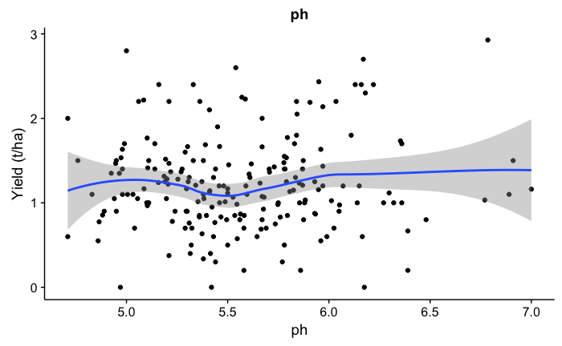

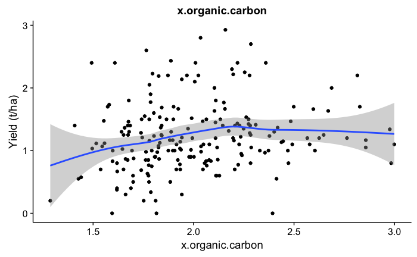

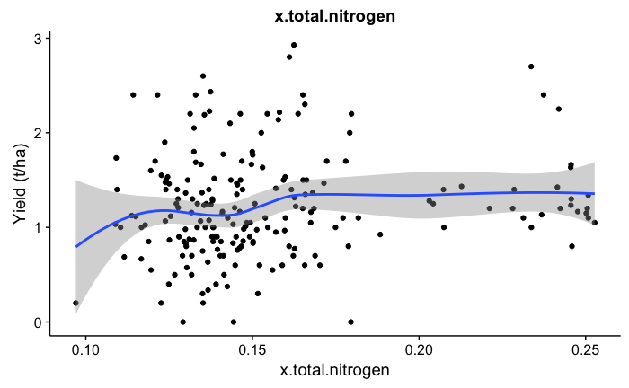

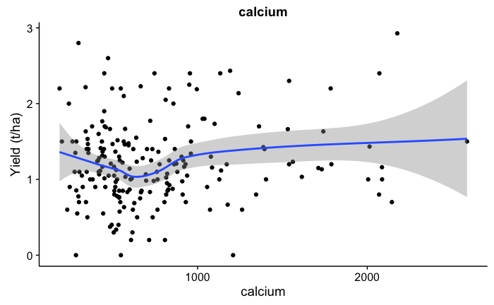

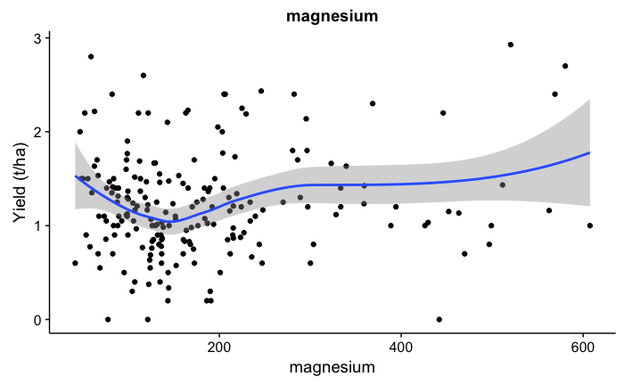

```r
for(i in 1:length(keySoilVars)){
  print(
  ggplot(aggCell, aes(x = aggCell[,keySoilVars[i]], y = tha)) +
    geom_point() +
    stat_smooth() +
    #stat_smooth(method="lm", color="red")+
    labs(title = keySoilVars[i], x= keySoilVars[i], y="Yield (t/ha)")
  )
}
```

The cell level results seem a bit more useable (??? big question mark). I’ll try to fit the expected relationship to these data and see where the coefficients cancel each other out

```r
aggTab <- do.call(rbind, lapply(keySoilVars, function(x){
  pdrFunction(aggCell, x, aggCell$tha)
}))
kable(aggTab, format="markdown")
```

| var | result |
| --- | --- |
| ph | NR |
| x.organic.carbon | 2.42 |
| x.total.nitrogen | 0.23 |
| calcium | NR |
| magnesium | NR |

## 4.4 Wet chem only

```r
pairedWetDir <- normalizePath(file.path("..", "..", "OAF Soil Lab Folder", "Projects", "rw_shs_16b_paired_climbing", "3_wet_chem"))
pairedWet <- read.csv(file=paste(pairedWetDir, "wet_chem.csv", sep = "/"))
pSoilIdDir <- normalizePath(file.path("..", "..", "OAF Soil Lab Folder", "Projects", "rw_shs_16b_paired_climbing", "5_merged"))
pSoilIds <- read.csv(file=paste(pSoilIdDir, "database.csv", sep = "/"))
pairedWet <- pairedWet %>%
  mutate(
    Field.Name = tolower(Field.Name)
  ) %>%
  rename(
    LAB.SSN = Field.Name
  ) %>%
  filter(LAB.SSN!="") %>%
  left_join(., pSoilIds, by="LAB.SSN") %>%
  rename(
    ssn = LAB.SSN
  ) %>%
  left_join(., py[,c("tha", "ssn")], by="ssn")
names(pairedWet) <- tolower(names(pairedWet))
```

Check out what is not merging. Visually we just don’t seem to have full matches. I don’t understand how that’s possible though given that we used these wet chem values to predict the soil values.

```r
# pairedWet$ssn[is.na(pairedWet$tha)]
#
# pairedWet$ssn[!pairedWet$ssn %in% py$ssn]
# sort(py$ssn[!py$ssn %in% pairedWet$ssn])
#py$ssn[grep("35", py$ssn)]
```

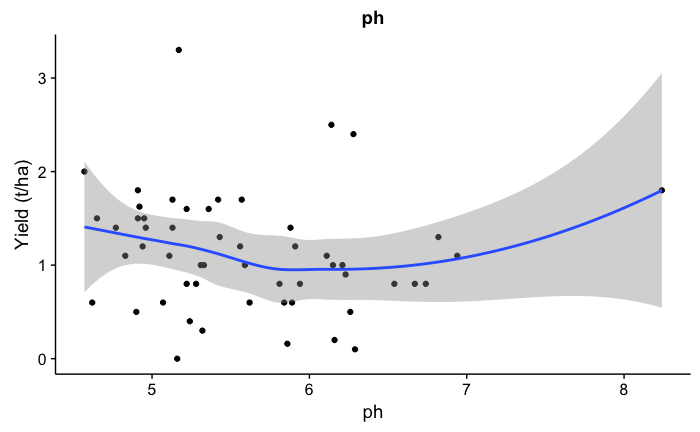

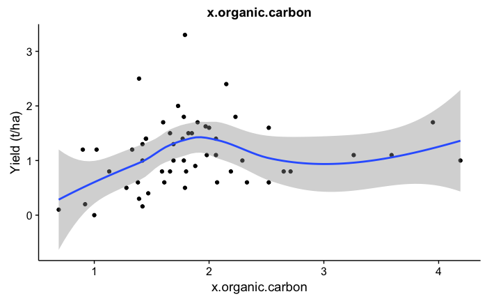

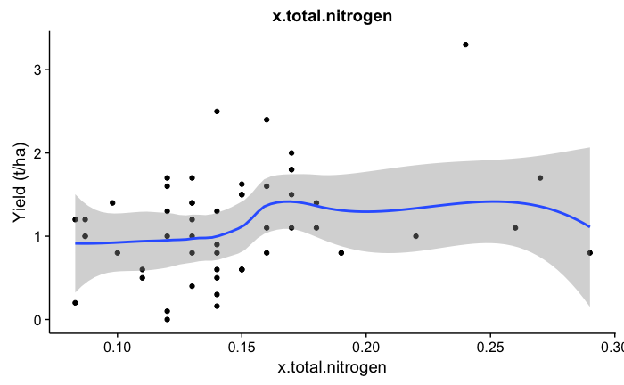

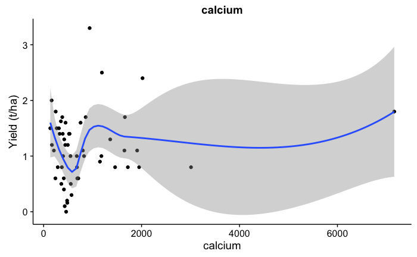

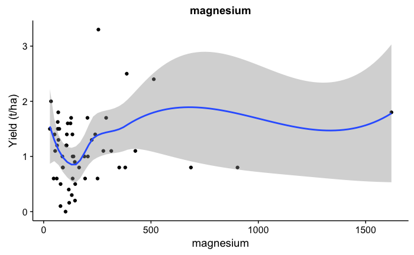

```r
for(i in 1:length(keySoilVars)){
  print(
  ggplot(pairedWet, aes(x = pairedWet[,keySoilVars[i]], y = tha)) +
    geom_point() +
    stat_smooth() +
    #stat_smooth(method="lm", color="red")+
    labs(title = keySoilVars[i], x= keySoilVars[i], y="Yield (t/ha)")
  )
}
```

Quick overview:

**Reminder**: the curves on these models is a loess curve. Loess takes a local average to derive a line of best fit. This line is by design very responsive to the data and not the model we’re using to detect the point of diminishing returns. It’s a good first check to see if it’s worth investigating.

- pH again doesn’t make much sense
- Carbon looks alright. Let’s take a closer look
- Nitrogen looks useable as well.
- Calcium looks really odd
- Magnesium looks like calcium; really odd.

```r
wetPdrTab <- do.call(rbind, lapply(keySoilVars, function(x){
  pdrFunction(pairedWet, x, pairedWet$tha)
}))
kable(wetPdrTab, format="markdown")
```

| var | result |
| --- | --- |
| ph | NR |
| x.organic.carbon | 2.74 |
| x.total.nitrogen | 0.27 |
| calcium | 28047.76 |
| magnesium | 2174.75 |

## 4.5 Random Forest / PDP

Try looking at partial dependence plots to have a clear functional form to eyeball a tipping point in changes in pH on yield. This would likely be pretty difficult because pH may not be important in the ranked importance plots and it might not a functional form that fits with what we expect.

**Don’t do this as I don’t think this is an appropriate application of PDPs**

## 4.6 Summary

| source | var | result |
| --- | --- | --- |
| aggTab | ph | NR |
| aggTab | x.organic.carbon | 2.42 |
| aggTab | x.total.nitrogen | 0.23 |
| aggTab | calcium | NR |
| aggTab | magnesium | NR |
| indPdrTab | ph | NR |
| indPdrTab | x.organic.carbon | 2.44 |
| indPdrTab | x.total.nitrogen | 0.2 |
| indPdrTab | calcium | NR |
| indPdrTab | magnesium | NR |
| wetPdrTab | ph | NR |
| wetPdrTab | x.organic.carbon | 2.74 |
| wetPdrTab | x.total.nitrogen | 0.27 |
| wetPdrTab | calcium | 28047.76 |
| wetPdrTab | magnesium | 2174.75 |

# 5 Soil quartile

```r
yQuartiles <- function(yVar, xVar, df){
  applyCuts = cut(df[,xVar], breaks=quantile(df[,xVar],c(0.25, 0.5, 0.75, 1),type=1, na.rm=T))
  tab = tapply(df[,yVar], applyCuts, mean)
  #diff = tab[[4]] - tab[[1]]
  return(tab)
}

yQChange <- function(tab, start, end){ #start and end are the indicies
  diff = tab[[end]]-tab[[start]]
  return(diff)
}

qTab <- do.call(rbind, lapply(keySoilVars, function(x){
  yQuartiles("tha", x, py)
}))
qTab <- as.data.frame(qTab)
names(qTab) <- c("q25to50","q50to75","q75to100")

qTab <- as.data.frame(sapply(qTab, function(x){round(x,2)}))

qTab <- cbind(qTab,
              diff25to50 = apply(qTab, 1, function(x){
                  yQChange(x,1,2)}),
              diff50to75 = apply(qTab, 1, function(x){
                  yQChange(x,2,3)}))
```

Add in revenue calculation. Assume farmers are making 52 cents a kg

```r
library(scales)
# add revenue
marketValueT <- 520
numFarmersRw <- 164500/4
qTab$revenueA <- dollar(qTab$diff25to50 * marketValueT)
qTab$revenueB <- dollar(qTab$diff50to75 * marketValueT)

write.csv(qTab, file="output/quartileCalc.csv")
```

## 5.1 Minimum Threshold

```r
minThresh <- function(xVar, yVar, per.thold, thold, FarmerCount, marketValue, df){
  # figure out where the threshold is in terms of percentile of xVar
  # calculate value of moving farmers below that percentile above that perentile in terms of yield gain

  dist <- ecdf(df[,xVar])
  perce <- dist(thold)

  # amount above thold
  inClear <- 1-perce
  remainToMove <- ifelse(per.thold-inClear>0, per.thold - inClear, 0)
  remainToMoveFarmers <- FarmerCount*remainToMove

  startingPointX <- quantile(df[,xVar], c(perce - remainToMove), type=1, na.rm = T)[[1]]

  # yield value above threshold
  above <- mean(df[,yVar][df[,xVar]>thold], na.rm = T) #this is the average for all above threshold

  #distance between farmers yield value and threshold yield value for farmers below threshold and within the percentile we want to move up.

  remaining <-subset(df, df[,xVar]>=startingPointX & df[,xVar]<=thold)
  bump <- above - remaining[,yVar]

  marketValuetha <- marketValue*1000

  #average value add
  res <-mean(bump, na.rm = T) * remainToMoveFarmers * marketValuetha
  res <- paste(format(round(res / 1e6, 2), trim = TRUE), "M")


  return(res)
}

progImpactpH <- minThresh("ph", "tha", 0.75, 5.8, 282228, 0.52, py)
progImpactN <- minThresh("x.total.nitrogen", "tha", 0.75, 0.1, 282228, 0.52, py)
progImpactC <- minThresh("x.organic.carbon", "tha", 0.75, 2, 282228, 0.52, py)
progImpactCa <- minThresh("calcium", "tha", 0.75, 1056, 282228, 0.52, py)
progImpactMg <- minThresh("magnesium", "tha", 0.75, 148, 282228, 0.52, py)

progObj <- ls()[grep("progImpact", ls())]

progImpTab <- do.call(rbind, lapply(progObj, function(x){get(x)}))
progImpTab <- data.frame(var = progObj, value = progImpTab)

write.csv(progImpTab, file=paste("output/", "rwandaThresholdTab.csv", sep=""), row.names = F)
```